# Dow Jones News Fund Data Instructors

(ver May 17, 2026)

[figure not shown]

**Kevin Blackistone**

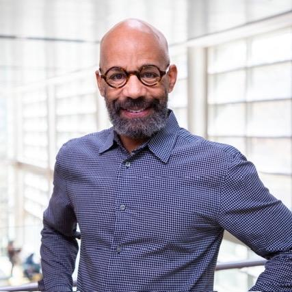

Kevin Blackistone is a longtime national sports columnist now at The Washington Post, a panelist on ESPN’s “Around the Horn,” a contributor to National Public Radio and coauthor of “A Gift for Ron,” a memoir by former NFL star Everson Walls published in November 2009 that details his kidney donation to onetime teammate Ron Springs.

Blackistone was a sports columnist for AOL Fanhouse from October 2007 to March 2011 and an award-winning sports columnist for The Dallas Morning News from September 1990 to September 2006.

Blackistone is a recipient of numerous awards, including awards for sports column writing from the Texas Associated Press Managing Editors, for investigative reporting from the Chicago Newspaper Guild and for enterprise reporting from the National Association of Black Journalists.

**Karen Denny**

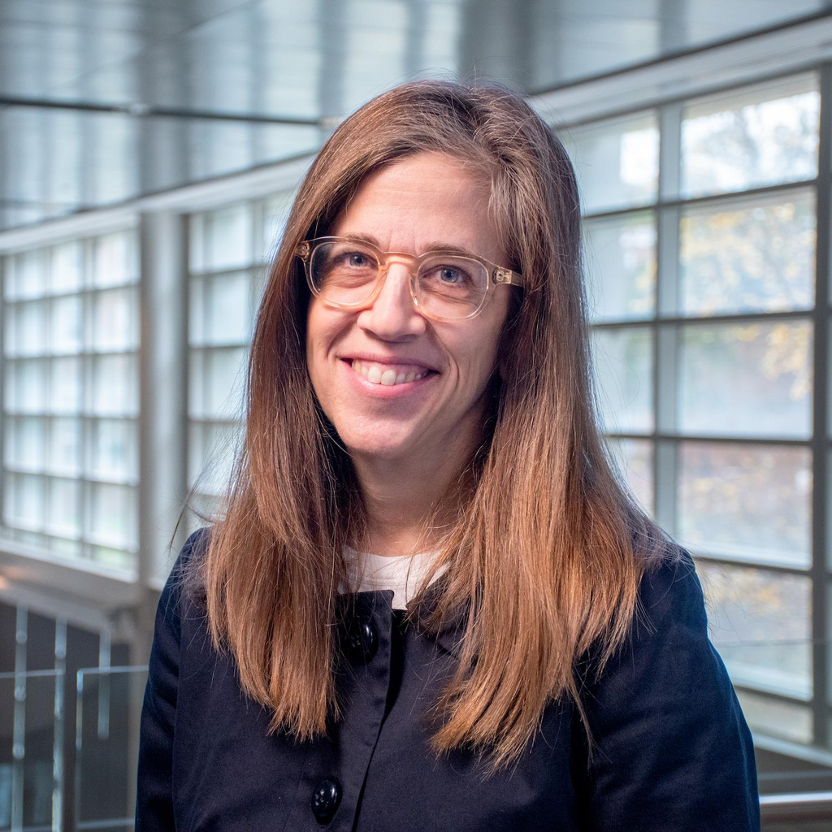

Karen Denny is Merrill College’s director of internships and career development. She previously served as the Annapolis bureau director of the Capital News Service, until taking over leadership of the career center at the beginning of 2022. Denny is a former editor with the McClatchy-Tribune (formerly Knight Ridder/Tribune) News Service, where she founded the wire’s Newsfeatures and International sections, and most recently was a features editor.

She previously worked as the Maryland editor for The Washington Times, and at the suburban Journal Newspapers as an editor and local government reporter. She also served as a professor at Sang Ji University in Won Ju, South Korea.

**Adam Marton**

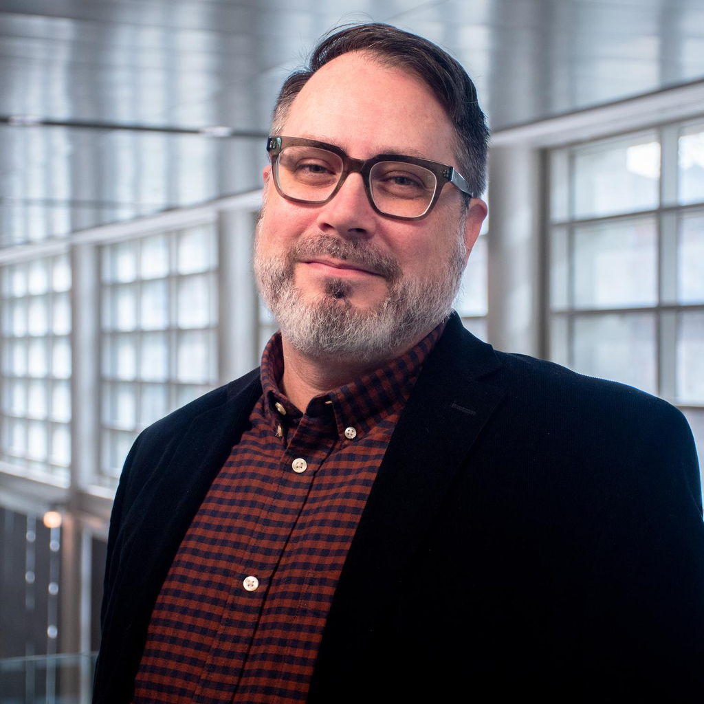

Adam Marton is an award-winning journalist and graphic designer who joined the Philip Merrill College of Journalism in 2018 after 13 years at The Baltimore Sun.

Marton is focused on quality storytelling across media, using design and technology to tell rich, human stories. He is a visual journalist and designer specializing in the presentation of the news, including data visualization, front-end development and information graphics.

**Bridget Lang**

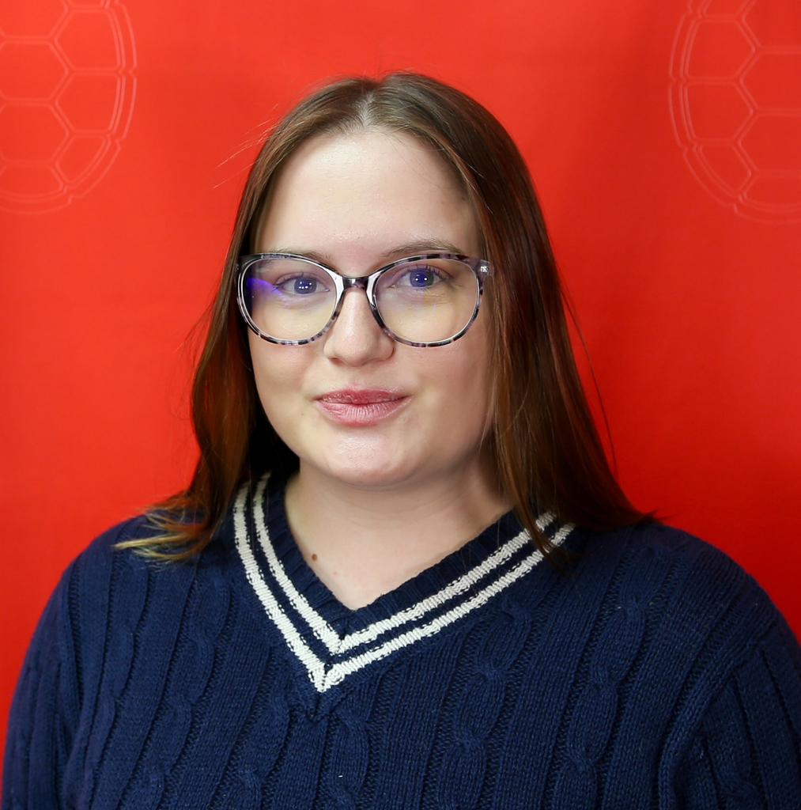

Bridget Lang is a software developer for the University of Maryland. In 2024, she earned her bachelor’s degree in computer science with an upper-level concentration in journalism. A Baltimore County native, Lang uses her skills in software development, data, and writing to tell stories in the best way possible. She has had articles published in the Baltimore Banner and Capital News Service and is assisting Wells on a research project about an influential conservative journalist.

**Christoph Mergerson**

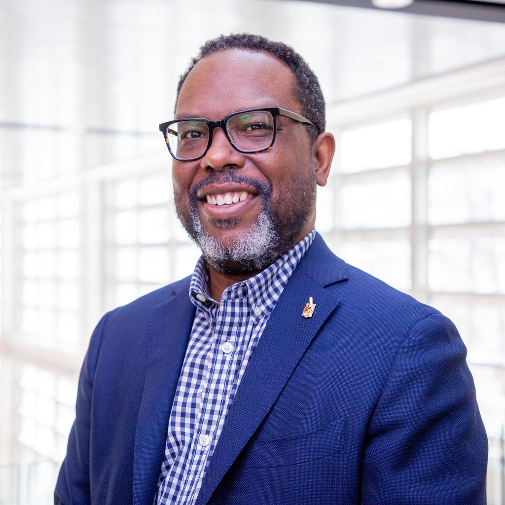

Christoph Mergerson, who completed his Ph.D. in Communication, Information and Media at Rutgers University, joined the Philip Merrill College of Journalism in Fall 2021 as a visiting assistant professor. He was appointed to the rank of assistant professor in Fall 2022.

Mergerson’s research and teaching interests include journalism history, weather journalism, race and media, and journalism and democracy. Mergerson arrived at Merrill with ongoing research that examines whether news media in the Southern United States are producing racially inclusive, public-service journalism. He brings award-winning classroom experience from teaching courses at Rutgers, including Communication Law and Global News.

**Daniel Trielli**

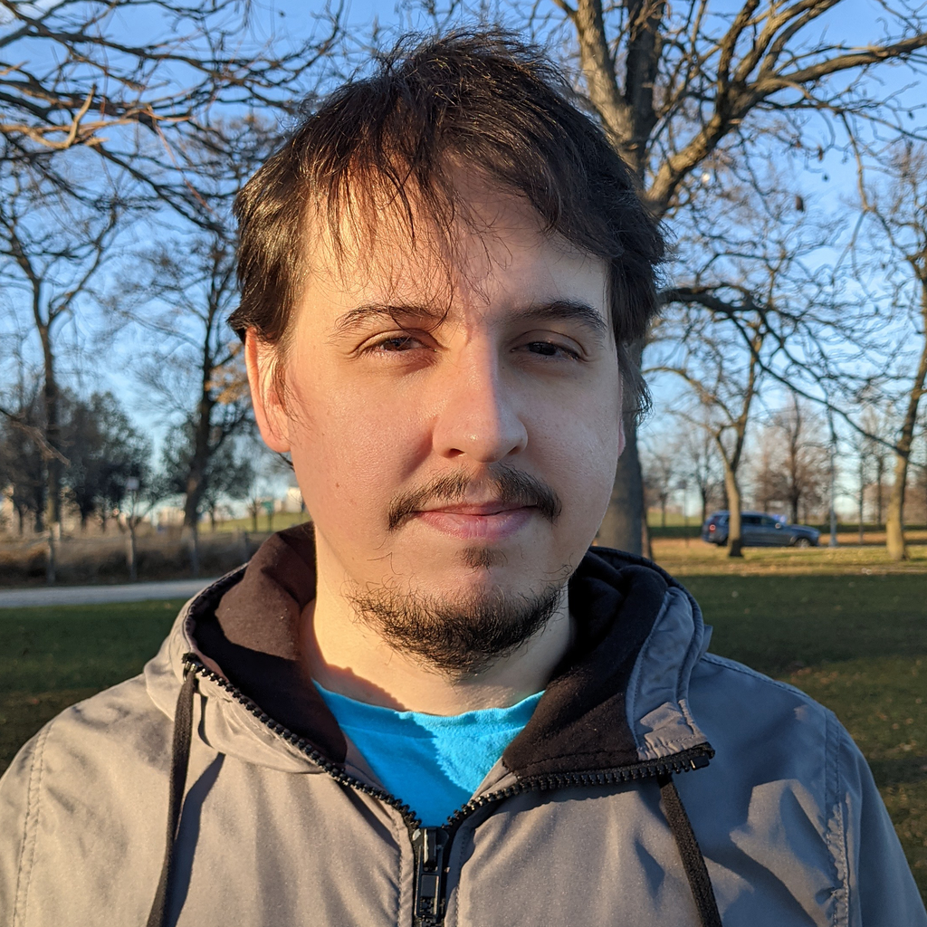

Daniel Trielli joined the Philip Merrill College of Journalism’s faculty in Fall 2023 as assistant professor of media and democracy.

He researches the impact of algorithmic curation on journalism and political information, and studies how Google affects the news and the audiences that use it to search. He is interested in data and computational journalism, media literacy and algorithmic accountability. Trielli came to Merrill College as a master’s student in 2015 after a 10-year career as a journalist in Brazil at the national newspaper, O Estado de S. Paulo, and the regional newspaper, Diário do Grande ABC.

**Rob Wells**

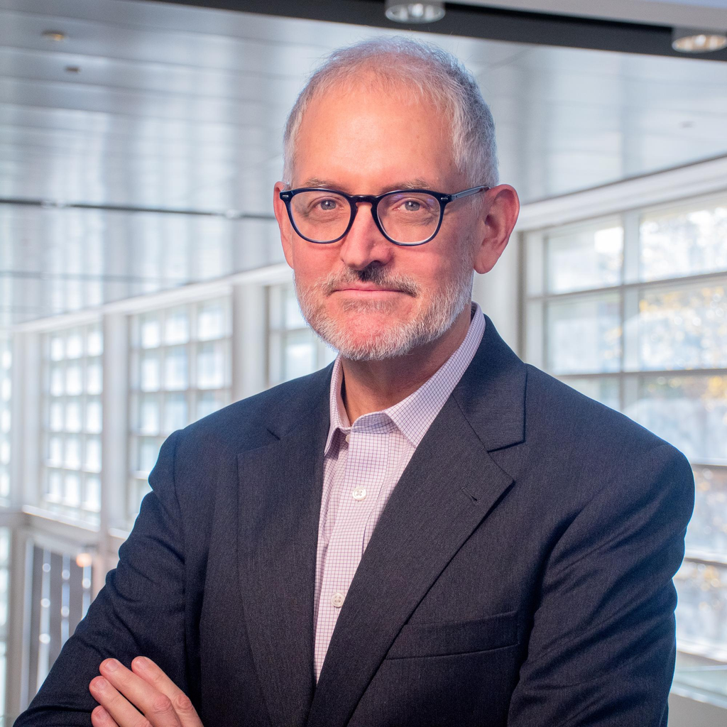

Rob Wells, a 2016 Ph.D. alum of Merrill College, returned to the university in the Spring 2022 semester after more than five years at the University of Arkansas, where he rose to the rank of associate professor and led Arkansas’ journalism graduate program. Wells has more than two decades of business journalism experience at The Associated Press, Bloomberg News and The Wall Street Journal.

Wells is the author of “The Enforcers: How Little-Known Trade Reporters Exposed the Keating Five and Advanced Business Journalism” (2019) and “The Insider: How the Kiplinger Newsletter Bridged Washington and Wall Street” (2022).

**Derek Willis**

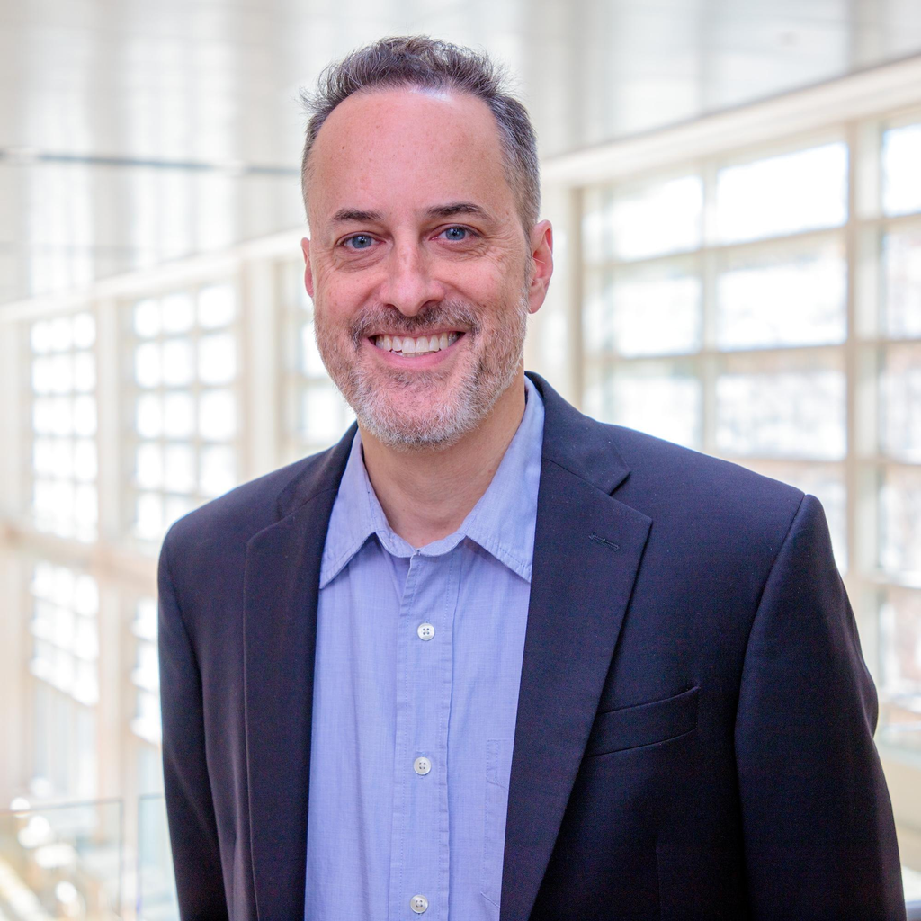

Derek Willis, one of the nation’s leading data journalists and an experienced educator, joined the Philip Merrill College of Journalism in Fall 2021 as a lecturer in data and computational journalism.

Willis came to Merrill College having spent 25 years winning awards at some of the top news outlets in the country. His latest stop was ProPublica, where he served as a news applications developer since 2015.

He previously held interactive journalism roles with The New York Times and The Washington Post, after working as a database reporter for The Washington Post, The Center for Public Integrity, Congressional Quarterly and The Palm Beach Post.

**Aidan Hughes**

[figure not shown]

Aidan Hughes is a data journalist at the University of Maryland’s Howard Center for Investigative Journalism. A former fellow at the Howard Center, Hughes has helped lead a variety of investigative and data projects including an Investigative Reporters and Editors Award-winning series on privately sponsored travel for members of Congress.

Before coming to UMD, Hughes worked in data privacy at a health care data and analytics company. In addition to his master’s degree from the University of Maryland, he earned a master’s in Conflict Transformation & Social Justice from Queen’s University Belfast, and a bachelor’s in International Studies and Creative Writing from Virginia Tech.